# HMDA Analysis

Alexander Proctor

May 18, 2018

# Introduction

## What is the HMDA?

In 1975, Congress passed the Home Mortgage Disclosure Act (HMDA for short) to address concerns that financial institutions were unfairly denying loans to applicants from certain areas, or making decisions based on protected classes. The act does not impose any financial requirements on the institutions, instead requiring them to publish data for each loan granted or denied. Thus, the impetus is on the general public to determine if lenders are acting unethically.

Data specifications for HMDA-disclosed data are available from the Federal Financial Institutions Examination Council (FFIEC). Specifications for 2008 specifically were retrived from https://www.ffiec.gov/hmda/pdf/spec2008.pdf; general codes (such as those for action_type) were retrieved from https://www.ffiec.gov/hmda/pdf/code.pdf.

## Loading the data

First, we need to load the data into R using the read_csv function.

The data was published as a single csv file containing roughly 17 million entities (individual loans) across 45 attributes. Since this is far too much data for R to handle (loading from csv takes well over an hour) I will be working with a random sample of 170,000 loans (1% of the data).

```r
library(tidyverse)

filename <- "C:/Users/Alex/Desktop/CMSC320/FINAL/2008HMDALAR.csv"

cols <- c("year","respondent_ID","agency_code","loan_type","property_type", "loan_purpose","occupancy","loan_amount","preapproval","action_type","MSA/MD","state_code","county_code","census_tract_number","applicant_ethnicity","co_applicant_ethnicity","applicant_race_1","applicant_race_2","applicant_race_3","applicant_race_4","applicant_race_5","co_applicant_race_1","co_applicant_race_2","co_applicant_race_3","co_applicant_race_4","co_applicant_race_5","applicant_sex","co_applicant_sex","applicant_income","purchaser_type","denial_reason_1","denial_reason_2","denial_reason_3","rate_spread","HOEPA_status","lien_status","edit_status","sequence_number","population","minority_population_pct","HUD_median_family_income","tract_to_MSA/MD_income_pct","owner_occupied_unit_num","1-to-4-family_unit_num","prior_to_2004")

hmda_2008_full <- read_csv(file=filename, col_names = cols)

hmda_smpl <- hmda_2008_full %>% sample_frac(0.01)
hmda_smpl
```

# Data wrangling

```r
# percent of primary applicants listed as more than one race
nrow(hmda_smpl %>% filter(!is.na(applicant_race_2)))/nrow(hmda_smpl) * 100
```

```
## [1] 0.411118
```

```r
# pct interracial couple applicants
nrow(hmda_smpl %>% filter(applicant_race_1 != co_applicant_race_2))/nrow(hmda_smpl) * 100
```

```
## [1] 0.120173
```

```r
# pct sex not recorded
nrow(hmda_smpl %>% filter(!(applicant_sex == 1 | applicant_sex == 2)))/nrow(hmda_smpl) * 100
```

```
## [1] 13.97686
```

```r
# same-sex co-applicant
nrow(hmda_smpl %>% filter(applicant_sex == co_applicant_sex))/nrow(hmda_smpl) * 100
```

```
## [1] 9.774259
```

```r
# removing extraneous info
hmda_smpl <- hmda_smpl %>%
  select(loan_amount, action_type, state_code, county_code, race=applicant_race_1, sex=applicant_sex,
         income=applicant_income, median_income=HUD_median_family_income)

# replacing nonexistant code with NA and removing
hmda_smpl <- hmda_smpl %>%
  mutate(sex=ifelse(sex != 1 & sex != 2, NA, sex),
         race=ifelse(race == 7, NA, race)) %>%
  na.omit(hmda_smpl)

# fixing column specs
hmda_smpl <- hmda_smpl %>%

  # removing leading zeroes
  mutate(loan_amount=sub("^0+", "", loan_amount),
         income=sub("^0+", "", income),
         median_income=sub("^0+", "", median_income)) %>%

  # multiplying by $1,000
  mutate(loan_amount=paste(loan_amount,"000",sep=""),
         income=paste(income,"000",sep="")) %>%

  # specifying column datatype
  mutate(loan_amount=as.integer(loan_amount),
         income=as.integer(income),
         median_income=as.integer(median_income))
```

# Plotting

With our data in a tidier form, we can start to look deeper. Let’s look at how loans vary over geography!

R’s usmap library allows us to display geographical data for the United States. The plot_usmap() function requires a data frame with exactly two columns: fips and values. FIPS (Federal Information Processing Standards) state codes are unique two-digit numbers mapped to states/territories, while 5-digit state+county codes do the same on a finer scale. Plot_usmap() takes these fips/value pairs and converts them into a ggplot-compliant map object. Luckily, our data is already in this form; we only need to combine the columns.

Just to start, let’s show how to use this tool with a simple median income x county map:

```r
library(usmap)
```

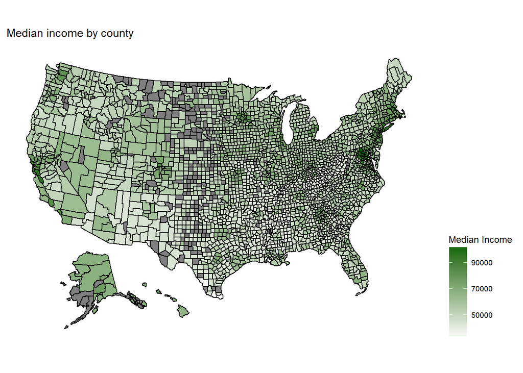

```r
# combining codes
hmda_smpl <- hmda_smpl %>%
  mutate(fips=paste(state_code, county_code, sep=""))

# selecting unique data - one value per fips code
income_data <- hmda_smpl %>%
  select(fips, value=median_income) %>%
  unique.data.frame()

# mapping
plot_usmap(data=income_data, regions="counties", values="value") +
  scale_fill_continuous(low = "white", high = "darkgreen", name = "Median Income") +
  labs(title = "Median income by county") +
  theme(legend.position = "right")
```

We are missing some data from the more sparsely-populated counties - less people means less houses means less home loans, after all.

We can see some tight concentrations of high income in certain counties, but our data is in largely inscrutable FIPS form. Let’s use the county.fips database from the maps package to convert to a readable form.

```r
library(maps)
data(county.fips) # loading the data

hmda_smpl %>%
  arrange(desc(median_income)) %>%
  select(fips, median_income) %>%
  unique.data.frame() %>%
  slice(1:10) %>%
  mutate(fips=as.integer(fips)) %>%
  left_join(county.fips, by="fips") %>%
  select(median_income, county=polyname)
```

```
## # A tibble: 10 x 2
##    median_income county
##            <int> <chr>
##  1        104400 maryland,montgomery
##  2        104400 maryland,frederick
##  3         97800 california,santa clara
##  4         97800 california,san benito
##  5         97500 connecticut,fairfield
##  6         97200 district of columbia,washington
##  7         97200 virginia,fairfax
##  8         97200 maryland,prince georges
##  9         97200 virginia,arlington
## 10         97200 virginia,prince william
```

Looks like the DC suburbs and Bay Area top the list, as expected.

Let’s use this to make some more interesting observations. How does the average amount of money requested change by county? Are there any counties where the average loans requested are substantially higher or lower than median income?

```r
loan_amt_data <- hmda_smpl %>%
  group_by(fips) %>%
  mutate(value=mean(loan_amount)) %>%
  select(fips, value) %>%
  unique.data.frame()

plot_usmap(data=loan_amt_data, regions="counties", values="value") +
  scale_fill_continuous(low = "white", high = "red", name = "Average Loan Amount") +
  labs(title = "Mean loan requested by county") +
  theme(legend.position = "right")
```

[output not shown]

```r
hmda_smpl %>%
  mutate(fips=as.integer(fips)) %>%
  group_by(fips) %>%
  mutate(avg_loan=mean(loan_amount)) %>%
  ungroup() %>%
  arrange(desc(avg_loan)) %>%
  select(fips, avg_loan) %>%
  unique.data.frame() %>%
  slice(1:10) %>%
  left_join(county.fips, by="fips") %>%
  select(avg_loan, county=polyname)
```

[output not shown]

```r
# calculating z scores and removing anything more than
# 2 standard deviations from the mean
hmda_standard <- hmda_smpl %>%
  group_by(fips) %>%
  mutate(mean_loan=mean(loan_amount)) %>%
  mutate(sd_loan=sd(loan_amount), sd_income=sd(income)) %>%
  mutate(z_loan=(loan_amount-mean_loan)/sd_loan, z_income=(income-median_income)/sd_income) %>%
  filter(z_loan > -2 & z_loan < 2 & z_income > -2 & z_income < 2)

loan_data <- hmda_standard %>%
  group_by(fips) %>%
  mutate(mean_loan=mean(loan_amount)) %>%
  ungroup() %>%
  select(fips, value=mean_loan) %>%
  unique.data.frame()

plot_usmap(data=loan_data, regions="counties", values="value") +
  scale_fill_continuous(low = "white", high = "red", name = "Average Loan Amount") +
  labs(title = "Mean loan requested by county") +
  theme(legend.position = "right")

loan_data %>%
  mutate(fips=as.integer(fips)) %>%
  arrange(desc(value)) %>%
  select(fips, value) %>%
  slice(1:5) %>%
  left_join(county.fips, by="fips") %>%
  select(value, county=polyname)
```

[output not shown]

Let’s take one last look at the geographical data. How does the ratio of loan-requested and individual income vary by area? Are people being forced to take on much riskier loans in certain areas, or are salaries largely commensurate with housing prices?

```r
ratio_data <- hmda_standard %>%
  filter(income > 1000) %>% # single outlier
  group_by(fips) %>%
  mutate(ratio=loan_amount/income) %>%
  mutate(value=mean(ratio)) %>%
  ungroup() %>%
  select(fips, value) %>%
  unique.data.frame()

plot_usmap(data=ratio_data, regions="counties", values="value") +
  scale_fill_continuous(low = "white", high = "red", name = "Average Loan:Income Ratio") +
  labs(title = "Loan:Income ratio by county") +
  theme(legend.position = "right")

ratio_data %>%
  mutate(fips=as.integer(fips)) %>%
  arrange(desc(value)) %>%
  select(fips, value) %>%
  slice(1:5) %>%
  left_join(county.fips, by="fips") %>%
  select(fips, value, county=polyname)
```

[output not shown]

```r
hmda_standard %>%
  filter(income < 200000 & income > 1000) %>%
  ggplot(aes(x=income, y=loan_amount)) +
  geom_point() + geom_smooth(method=lm)
```

[output not shown]

# Modeling

# Concerns

```r
num_to_str <- function(num) {
  c("amerindian","asian","black","hispanic","white","other")[[num]]
}

hmda_standard %>%
  mutate(application_denied=ifelse(action_type==3|action_type==5, 1, 0),
         race=factor(race)) %>%
  filter(action_type != 4 & action_type != 6) %>%
  group_by(race) %>%
  summarize(pct_denied=mean(application_denied)*100) %>%
  select(race, pct_denied) %>%
  unique.data.frame() %>%

  ggplot(aes(x=race, y=pct_denied)) + geom_histogram(stat="identity")
```

[output not shown]